# Dados de gastos de parlamentares

Análise de Dados 1 - Rafaelle Xavier

```r
knitr::opts_chunk$set(echo=TRUE, warning=FALSE, message=FALSE, fig.width=12, fig.height=6)
```

Dados de gastos dos deputados de um periodo recente. Os dados são compostos por 572 parlamentares. Para o estudo iremos sempre utilizar o valor líquido, que em nossos dados, representa a diferença entre o valor do documento e o valor da Glosa.

```r
gastos = read.csv("ano-atual.csv",  encoding="UTF-8")
```

Os gastos dos parlamentares são divididos em 18 categorias.

## Pergunta 2A

**Em que tipo de despesas nossos parlamentares gastam mais recursos de sua cota?**

Para responder a pergunta proposta, separamos os gastos de cada deputado por categoria de gasto, com isso, podemos selecionar apenas o “Tipo de Gasto” com maior despesa para cada um dos parlamentares.

```r
tipo.maior.despesa.deputado = gastos %>%
  group_by(txtDescricao, txNomeParlamentar) %>%
  summarise(total.despesa = sum(vlrLiquido)) %>%
  ungroup(tipo.maior.despesa.deputado) %>%
  group_by(txNomeParlamentar ) %>%
  filter(total.despesa == max(total.despesa))
```

Agora agruparemos, usando a tabela anteriormente gerada, por “Tipo de Gasto” para obter qual categoria os deputados mais gastam.

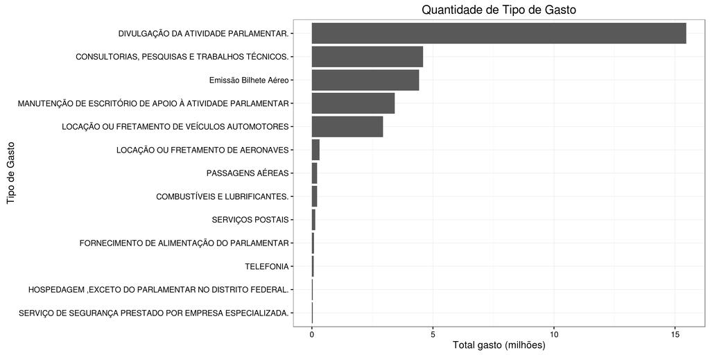

```r
total.tipo.despesa = tipo.maior.despesa.deputado %>%
  group_by(txtDescricao) %>%
  summarise(total = sum(total.despesa))

grafico.valor.tipo.despesa = ggplot(total.tipo.despesa, aes(x = reorder(txtDescricao, total/1e6),y = total/1e6)) +
  geom_bar(stat = "identity") +
  xlab("Tipo de Gasto") +
  ylab("Total gasto (milhões)") +
  ggtitle("Quantidade de Tipo de Gasto") +
  coord_flip()

grafico.valor.tipo.despesa
```

Como podemos observar no gráfico, os três “Tipos de Gasto” com maiores custos da cota dos deputados são:

- Divulgação de Atividades Parlamentar;
- Consultorias, Pesquisa e Trabalhos Técnicos;
- Emissão de Bilhete Aéreo.

#### Pergunta 2B

**Quais tipos de despesas têm despesas que mais variam, que têm valores mais desiguais?**

Iremos gerar um gráfico para observar a distribuição dos gastos por categoria.

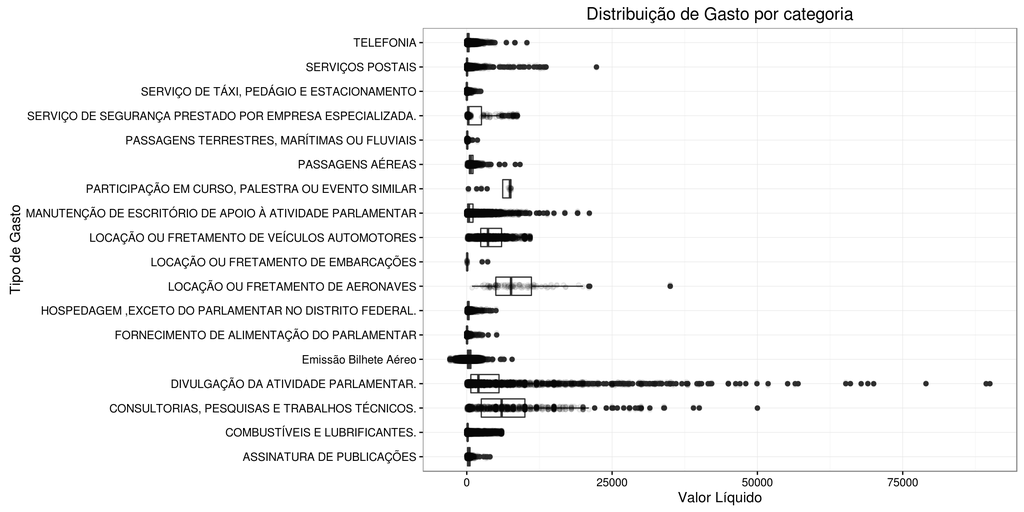

```r
ggplot(gastos, aes(txtDescricao, vlrLiquido)) +
  geom_boxplot() +
  xlab("Tipo de Gasto") +
  ylab("Valor Líquido") +
  ggtitle("Distribuição de Gasto por categoria") +
  coord_flip()+
  geom_point(position = position_jitter(width = .2), alpha = .07)
```

Calculando o desvio padrão dos gastos, para verificar quão distante os valores estão da média, temos o seguinte gráfico:

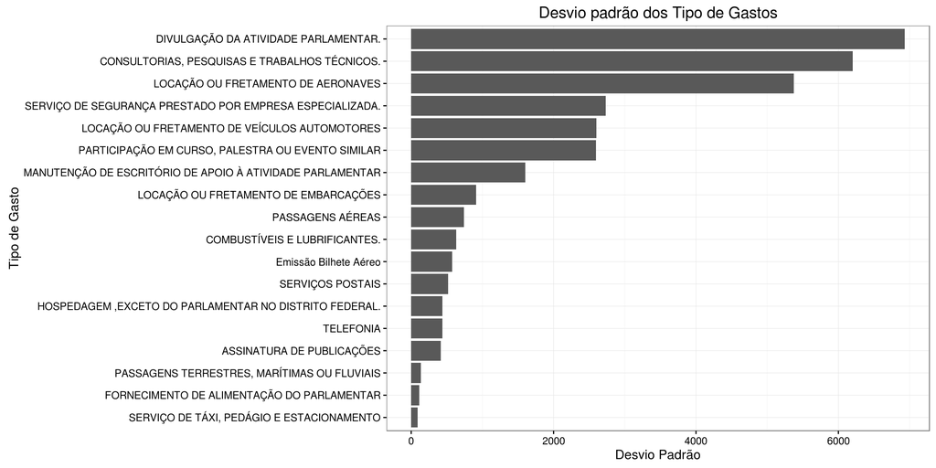

```r
ggplot(total.tipo.despesa.geral, aes(x = reorder(txtDescricao, desvioPadrao), y = desvioPadrao)) +
  geom_bar(stat = "identity")  +
  xlab("Tipo de Gasto") +
  ylab("Desvio Padrão") +
  ggtitle("Desvio padrão dos Tipo de Gastos") +
  coord_flip()
```

Como podemos verificar utilizando os dois gráficos, “Divulgação de Atividades Parlamentar” e “Consultorias, Pesquisa e Trabalhos Técnicos” são as duas categorias com maior variabilidade, já as categorias “Fornecimento de Alimentação do Parlamentar” e “Serviço de Táxi, Pedágio e Estacionamento” possuiem a menor variação.

Por possuir o maior gasto e a maior variabilidadeInicialmente iremos selecionar apenas a categoria “Divulgação da Atividade Parlamentar” para explorar um pouco mais os dados.

```r
summary(gastos$vlrLiquido)
```

```
##     Min.  1st Qu.   Median     Mean  3rd Qu.     Max.
## -2911.00    48.04   140.00   588.60   426.50 90000.00
```

Podemos observar uma grande diferença entre os valores de média e mediana, além disso, a diferença do valor máximo para a média é bastante elevada.

Agora agruparemos por estado o valor das despesas com Divulgação de Atividade Parlamentar.

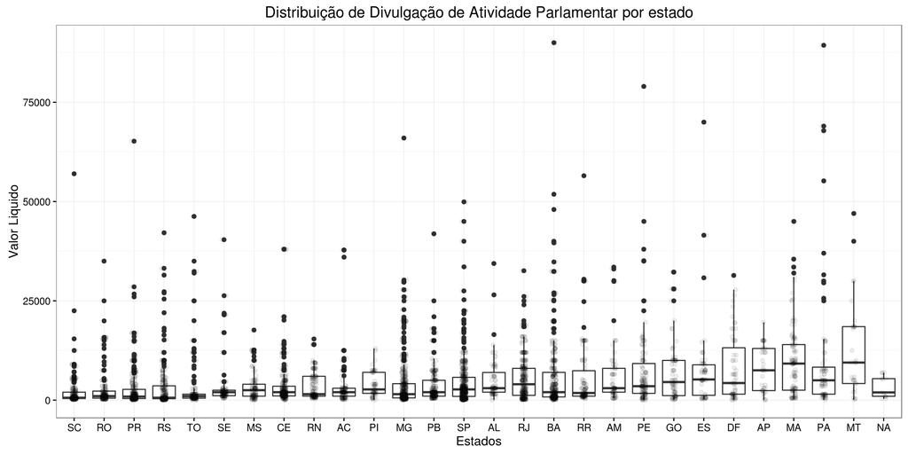

```r
divulgacao.estado = despesa.especifica %>%
  group_by(sgUF)

ggplot(divulgacao.estado, aes(x = reorder(sgUF, vlrLiquido), vlrLiquido)) +
  geom_boxplot() +
  xlab("Estados") +
  ylab("Valor Liquido") +
  ggtitle("Distribuição de Divulgação de Atividade Parlamentar por estado") +
  geom_point(position = position_jitter(width = .2), alpha = .07)
```

[figure not shown]

```r
total.divulgacao.estado = divulgacao.estado %>%
  group_by(sgUF) %>%
  summarise(total.divulgacao = sum(vlrLiquido), media.estado = mean(vlrLiquido))

ggplot(total.divulgacao.estado, aes(x = reorder(sgUF, total.divulgacao), y = total.divulgacao)) +
  geom_bar(stat = "identity")  +
  xlab("Tipo de Gasto") +
  ylab("Valor liquido") +
  ggtitle("Desvio padrão dos Tipo de Gastos") +
  theme(axis.text.x = element_text(angle = 45, hjust = 1))
```

Como podemos observar os três primeiros estados com maiores gastos na categoria são:

- São Paulo
- Bahia
- Minas Gerais

Existem diferenças bastante significativas, que influenciam em valores como média e mediana. Para uma melhor análise, seria necessário que o analista conhecesse mais profundamente o contexto e o significado das variaveis dos dados, para uma melhor investigação, conhecendo o motivo para os resultados verificados.